# Prediction of Maternal Health Risk Level

```python
#Importing Libraries
```

```python
import numpy as np
import pandas as pd
```

```python
import warnings
warnings.filterwarnings('ignore')
```

```python
#Importing the data
```

```python
data = pd.read_csv("C:/Users/TUSHAR/Documents/Maternal Health Risk Data Set.csv")
```

```python
data.head()
```

|  | Age | SystolicBP | DiastolicBP | BloodGlucoseLevel | BodyTemp | HeartRate | RiskLevel |
| --- | --- | --- | --- | --- | --- | --- | --- |
| 0 | 25 | 130 | 80 | 15.0 | 98.0 | 86 | high risk |
| 1 | 35 | 140 | 90 | 13.0 | 98.0 | 70 | high risk |
| 2 | 29 | 90 | 70 | 8.0 | 100.0 | 80 | high risk |
| 3 | 30 | 140 | 85 | 7.0 | 98.0 | 70 | high risk |
| 4 | 35 | 120 | 60 | 6.1 | 98.0 | 76 | low risk |

Age: Age in years when a women is pregnant. SystolicBP: Upper value of Blood Pressure in mmHg, another significant attribute during pregnancy. DiastolicBP: Lower value of Blood Pressure in mmHg, another significant attribute during pregnancy. BloodGlucoseLevel: Blood glucose levels is in terms of a molar concentration, mmol/L. BodyTemp: Body Temperature in degree fahrenheit. HeartRate: A normal resting heart rate in beats per minute. Risk Level: Predicted Risk Intensity Level during pregnancy considering the previous attribute. Target Attribute - Risk Level ---Classified as high risk, low risk, mid risk.

```python
data.shape
```

```
(1014, 7)
```

```python
data.info()
```

```
<class 'pandas.core.frame.DataFrame'>
RangeIndex: 1014 entries, 0 to 1013
Data columns (total 7 columns):
 #   Column             Non-Null Count  Dtype
---  ------             --------------  -----
 0   Age                1014 non-null   int64
 1   SystolicBP         1014 non-null   int64
 2   DiastolicBP        1014 non-null   int64
 3   BloodGlucoseLevel  1014 non-null   float64
 4   BodyTemp           1014 non-null   float64
 5   HeartRate          1014 non-null   int64
 6   RiskLevel          1014 non-null   object
dtypes: float64(2), int64(4), object(1)
memory usage: 55.6+ KB
```

# Basic Statistical description and understanding of dispersion of data

```python
data.describe().T
```

|  | count | mean | std | min | 25% | 50% | 75% | max |
| --- | --- | --- | --- | --- | --- | --- | --- | --- |
| Age | 1014.0 | 29.871795 | 13.474386 | 10.0 | 19.0 | 26.0 | 39.0 | 70.0 |
| SystolicBP | 1014.0 | 113.198225 | 18.403913 | 70.0 | 100.0 | 120.0 | 120.0 | 160.0 |
| DiastolicBP | 1014.0 | 76.460552 | 13.885796 | 49.0 | 65.0 | 80.0 | 90.0 | 100.0 |
| BloodGlucoseLevel | 1014.0 | 8.725986 | 3.293532 | 6.0 | 6.9 | 7.5 | 8.0 | 19.0 |
| BodyTemp | 1014.0 | 98.665089 | 1.371384 | 98.0 | 98.0 | 98.0 | 98.0 | 103.0 |
| HeartRate | 1014.0 | 74.301775 | 8.088702 | 7.0 | 70.0 | 76.0 | 80.0 | 90.0 |

```python
data.columns
```

```
Index(['Age', 'SystolicBP', 'DiastolicBP', 'BloodGlucoseLevel', 'BodyTemp',
       'HeartRate', 'RiskLevel'],
      dtype='object')
```

```python
data["RiskLevel"].unique()
```

```
array(['high risk', 'low risk', 'mid risk'], dtype=object)
```

# Checking for null values

```python
data.isnull().sum()
```

```
Age                  0
SystolicBP           0
DiastolicBP          0
BloodGlucoseLevel    0
BodyTemp             0
HeartRate            0
RiskLevel            0
dtype: int64
```

There are no null values present in the data.

```python
# Importing Libraries for visualisation
```

```python
import matplotlib.pyplot as plt
import seaborn as sns
```

# Checking for outliers

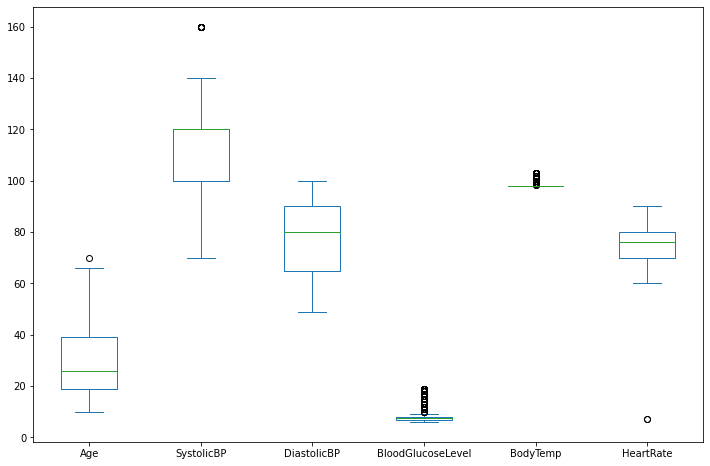

```python
data.plot(kind ="box",figsize=(12,8))
```

From above box-plot we can see some extreme values for some features,but sometimes these extreme values also has some siginficance.

# Removing outliers

```python
data = data[data.HeartRate>40]
```

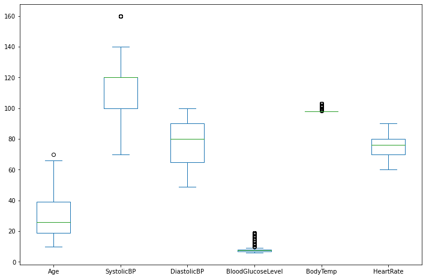

```python
data.plot(kind ="box",figsize=(12,8))
```

```python
data.shape
```

```
(1012, 7)
```

# Count plot for checking imbalance in the data

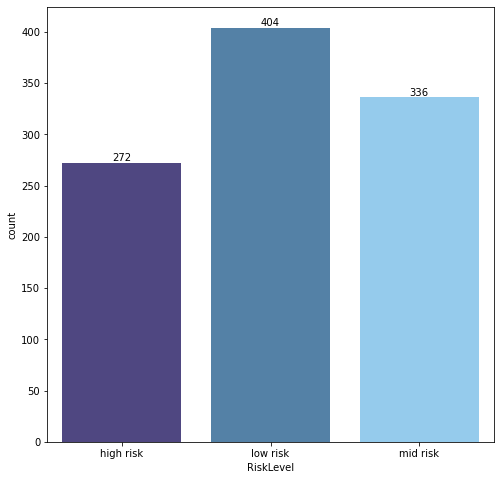

```python
plt.figure(figsize=(8,8))
colors=["#483D8B","#4682B4", "#87CEFA"]
ax = sns.countplot(data = data, x="RiskLevel", palette=colors)
ax.bar_label(ax.containers[0])
plt.show()
```

From above count plot we can say that class labels are somewhat imbalanced.

```python
data["RiskLevel"].replace(["low risk","mid risk","high risk"],[0,1,2],inplace = True)
data["RiskLevel"] = data["RiskLevel"].astype(float)
```

```python
data.head()
```

|  | Age | SystolicBP | DiastolicBP | BloodGlucoseLevel | BodyTemp | HeartRate | RiskLevel |
| --- | --- | --- | --- | --- | --- | --- | --- |
| 0 | 25 | 130 | 80 | 15.0 | 98.0 | 86 | 2.0 |
| 1 | 35 | 140 | 90 | 13.0 | 98.0 | 70 | 2.0 |
| 2 | 29 | 90 | 70 | 8.0 | 100.0 | 80 | 2.0 |
| 3 | 30 | 140 | 85 | 7.0 | 98.0 | 70 | 2.0 |
| 4 | 35 | 120 | 60 | 6.1 | 98.0 | 76 | 0.0 |

# Correlation Matrix of the data

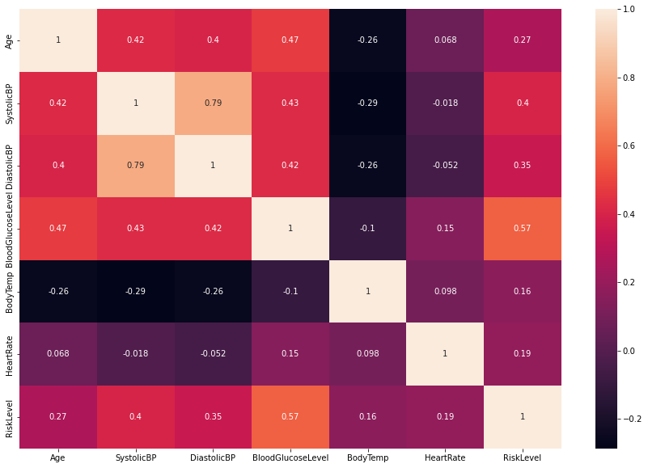

```python
plt.figure(figsize=(15,10))
sns.heatmap(data.corr(),annot=True)
```

Feature Blood Glucose Level is highly correlated with target feature Risk Level and other features also have significant correlation with target feature.

# Evaluating distributions of the features

```python
Columns = ["Age","SystolicBP","DiastolicBP","BloodGlucoseLevel","BodyTemp","HeartRate"]
```

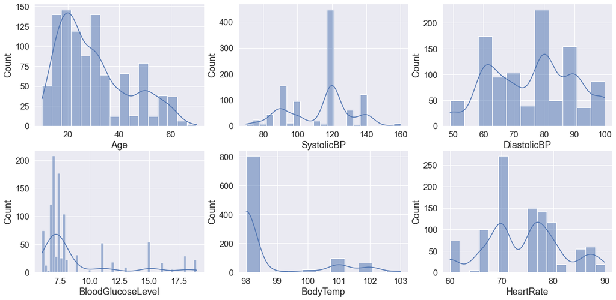

```python
plt.figure(figsize = (20,20))
sns.set(font_scale = 1.5)
for i, col in enumerate(Columns):
    ax = plt.subplot(4,3,i+1)
    sns.histplot(x = data[col], ax = ax,kde = True)
    plt.style
```

Features Age and Blood Glucose Level are positively skewed.

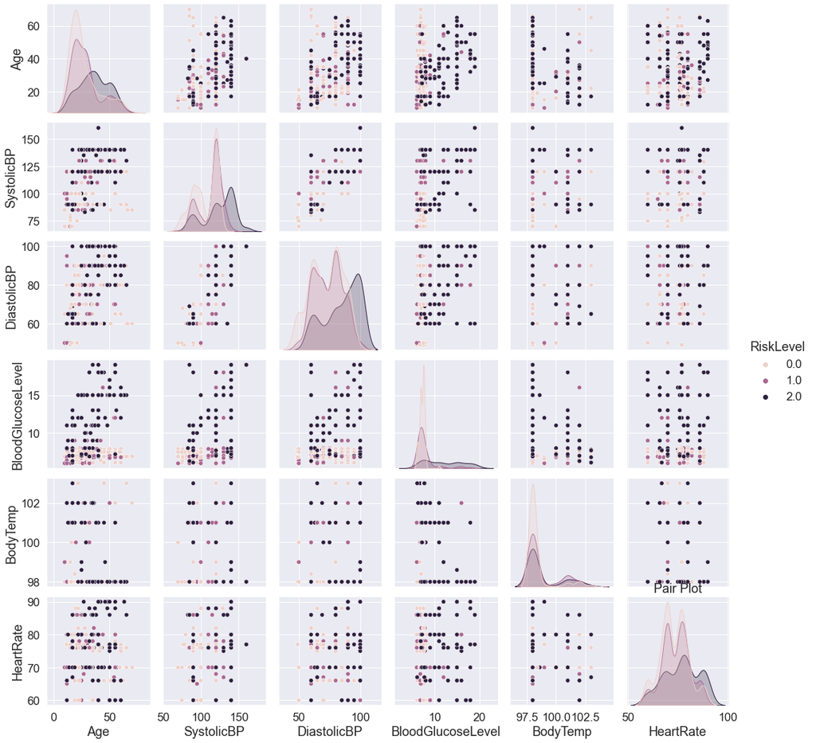

```python
sns.pairplot(data,hue="RiskLevel")
plt.title("Pair Plot")
```

# Plotting Features using Boxen Plot

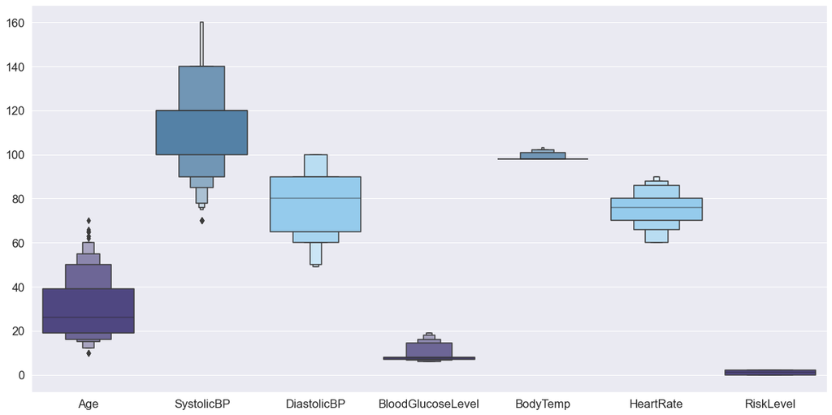

```python
plt.figure(figsize=(20,10))
sns.boxenplot(data = data,palette = colors)
plt.show()
```

The above plot shows the range of our feature attributes. All the features are in different ranges. To fit this in a model we must scale it to the same range.

# Scaling the Data

```python
# Defining independent and dependent attributes
X=data.drop(["RiskLevel"],axis=1)
y=data["RiskLevel"]
```

```python
from sklearn import preprocessing
from sklearn.preprocessing import StandardScaler
```

```python
#Set up a standard scaler for the features
col_names = list(X.columns)
s_scaler = preprocessing.StandardScaler()
X_scaled= s_scaler.fit_transform(X)
X_scaled = pd.DataFrame(X_scaled, columns=col_names)
X_scaled
```

|  | Age | SystolicBP | DiastolicBP | BloodGlucoseLevel | BodyTemp | HeartRate |
| --- | --- | --- | --- | --- | --- | --- |
| 0 | -0.363796 | 0.913349 | 0.254566 | 1.903633 | -0.485808 | 1.538308 |
| 1 | 0.378765 | 1.456516 | 0.974379 | 1.296644 | -0.485808 | -0.589878 |
| 2 | -0.066772 | -1.259323 | -0.465247 | -0.220828 | 0.972192 | 0.740239 |
| 3 | 0.007484 | 1.456516 | 0.614473 | -0.524323 | -0.485808 | -0.589878 |
| 4 | 0.378765 | 0.370181 | -1.185059 | -0.797468 | -0.485808 | 0.208192 |
| ... | ... | ... | ... | ... | ... | ... |
| 1007 | -0.586565 | 0.370181 | -1.185059 | 1.903633 | -0.485808 | 0.740239 |
| 1008 | 1.863888 | 0.370181 | 0.974379 | 2.814116 | -0.485808 | -1.919994 |
| 1009 | 0.378765 | -1.530907 | -1.185059 | 3.117610 | -0.485808 | 1.538308 |
| 1010 | 0.972814 | 0.370181 | 0.974379 | 2.814116 | -0.485808 | -0.589878 |
| 1011 | 0.155997 | 0.370181 | -0.825153 | -0.827817 | 1.701192 | 0.208192 |

1012 rows × 6 columns

```python
X_scaled.describe().T
```

|  | count | mean | std | min | 25% | 50% | 75% | max |
| --- | --- | --- | --- | --- | --- | --- | --- | --- |
| Age | 1012.0 | -1.919852e-19 | 1.000494 | -1.477638 | -0.809333 | -0.289540 | 0.675790 | 2.977730 |
| SystolicBP | 1012.0 | -3.387716e-16 | 1.000494 | -2.345659 | -0.716155 | 0.370181 | 0.370181 | 2.542852 |
| DiastolicBP | 1012.0 | 5.043177e-16 | 1.000494 | -1.976853 | -0.825153 | 0.254566 | 0.974379 | 1.694192 |
| BloodGlucoseLevel | 1012.0 | -2.753616e-17 | 1.000494 | -0.827817 | -0.554672 | -0.372575 | -0.220828 | 3.117610 |
| BodyTemp | 1012.0 | 4.411272e-15 | 1.000494 | -0.485808 | -0.485808 | -0.485808 | -0.485808 | 3.159191 |
| HeartRate | 1012.0 | -4.294435e-16 | 1.000494 | -1.919994 | -0.589878 | 0.208192 | 0.740239 | 2.070355 |

# Plotting the scaled features using boxen plots

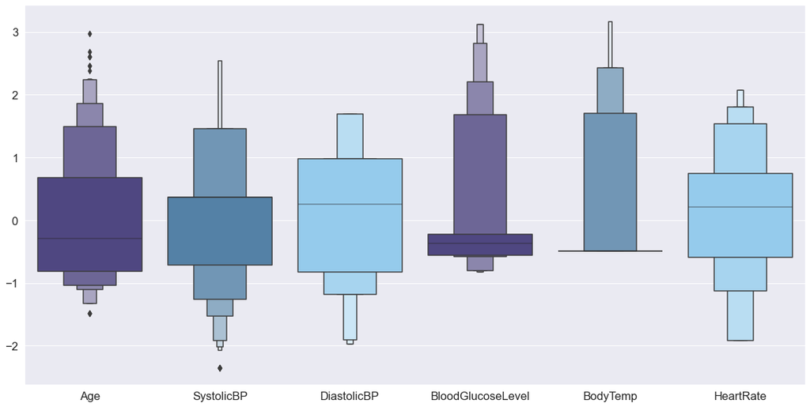

```python
plt.figure(figsize=(20,10))
sns.boxenplot(data = X_scaled,palette = colors)
plt.show()
```

The plot clearly indicates that all the features are in same range since we have scaled the data.

# Model Building

```python
#Splitting the data into training set and test set
```

```python
from sklearn.model_selection import train_test_split
```

```python
x_train, x_test,y_train, y_test = train_test_split( X_scaled,y,test_size=0.2,random_state=12)
```

```python
x_train.shape,y_train.shape
```

```
((809, 6), (809,))
```

```python
x_test.shape,y_test.shape
```

```
((203, 6), (203,))
```

```python
from sklearn.metrics import accuracy_score, confusion_matrix, classification_report, precision_score, recall_score, f1_score
```

# KNN

```python
from sklearn.neighbors import KNeighborsClassifier
kn = KNeighborsClassifier(n_neighbors=5)
kn.fit(x_train,y_train)
pred = kn.predict(x_test)
```

```python
accuracy_score(y_test,pred)
```

```
0.7044334975369458
```

```python
confusion_matrix(y_test,pred)
```

```
array([[66, 21,  0],
       [19, 37,  6],
       [ 2, 12, 40]], dtype=int64)
```

# Naive Bayes Classifier

```python
from sklearn.naive_bayes import GaussianNB
nb = GaussianNB()
nb.fit(x_train,y_train)
pred = nb.predict(x_test)
```

```python
accuracy_score(y_test,pred)
```

```
0.6108374384236454
```

```python
confusion_matrix(y_test,pred)
```

```
array([[77,  9,  1],
       [48, 10,  4],
       [ 5, 12, 37]], dtype=int64)
```

# SVC

```python
from sklearn.svm import SVC
from sklearn.svm import LinearSVC
svc = LinearSVC()
svc.fit(x_train,y_train)
pred = svc.predict(x_test)
```

```python
accuracy_score(y_test,pred)
```

```
0.6600985221674877
```

```python
confusion_matrix(y_test,pred)
```

```
array([[70, 16,  1],
       [35, 20,  7],
       [ 1,  9, 44]], dtype=int64)
```

# Decesion Tree

```python
from sklearn.tree import DecisionTreeClassifier
dt = DecisionTreeClassifier()
dt.fit(x_train,y_train)
pr = dt.predict(x_test)
```

```python
accuracy_score(y_test,pred)
```

```
0.6600985221674877
```

```python
confusion_matrix(y_test,pred)
```

```
array([[70, 16,  1],
       [35, 20,  7],
       [ 1,  9, 44]], dtype=int64)
```

# Random Forest

```python
from sklearn.ensemble import RandomForestClassifier
rf = RandomForestClassifier()
rf.fit(x_train,y_train)
pred = rf.predict(x_test)
```

```python
accuracy_score(y_test,pred)
```

```
0.8571428571428571
```

```python
confusion_matrix(y_test,pred)
```

```
array([[63, 23,  1],
       [ 2, 58,  2],
       [ 0,  1, 53]], dtype=int64)
```

# Gradient Boosting

```python
from sklearn.ensemble import GradientBoostingClassifier
model = GradientBoostingClassifier()
model.fit(x_train,y_train)
pred = model.predict(x_test)
```

```python
accuracy_score(y_test,pred)
```

```
0.8177339901477833
```

```python
confusion_matrix(y_test,pred)
```

```
array([[67, 20,  0],
       [10, 48,  4],
       [ 1,  2, 51]], dtype=int64)
```

So Random Forest does best amongst the models to be the most accurate.So we will choose Random Forest Model for Prediction.

# Random Forest Model

```python
rf = RandomForestClassifier()
rf.fit(x_train,y_train)
pred = rf.predict(x_test)
pred
```

```
array([0., 2., 1., 1., 1., 2., 1., 2., 0., 0., 2., 0., 1., 1., 0., 1., 0.,
       2., 0., 2., 0., 2., 1., 2., 0., 2., 0., 1., 1., 2., 1., 0., 1., 1.,
       1., 2., 1., 2., 1., 2., 1., 0., 1., 2., 0., 1., 1., 2., 1., 2., 1.,
       1., 2., 1., 0., 2., 2., 0., 0., 1., 1., 2., 1., 1., 1., 1., 0., 1.,
       1., 0., 0., 2., 1., 0., 0., 1., 1., 2., 1., 0., 1., 1., 0., 1., 0.,
       0., 0., 0., 0., 2., 0., 2., 0., 0., 0., 2., 1., 2., 0., 2., 1., 1.,
       0., 1., 0., 0., 0., 0., 0., 2., 1., 1., 0., 2., 1., 2., 1., 2., 2.,
       1., 2., 0., 1., 0., 2., 0., 1., 1., 1., 0., 0., 1., 1., 0., 2., 2.,
       2., 2., 0., 0., 1., 2., 0., 0., 1., 1., 0., 0., 0., 0., 0., 1., 2.,
       2., 0., 1., 1., 2., 2., 0., 1., 1., 0., 0., 0., 1., 1., 2., 2., 1.,
       1., 2., 1., 0., 2., 2., 0., 0., 1., 1., 0., 0., 2., 2., 1., 1., 1.,
       2., 1., 1., 0., 0., 0., 1., 2., 1., 1., 2., 0., 2., 2., 2., 2.])
```

```python
acccuracy = accuracy_score(y_test, pred)
recall = recall_score(y_test, pred, average="weighted")
precision = precision_score(y_test, pred, average="weighted")
f1_score = f1_score(y_test, pred, average="micro")

print("********* Random Forest Results *********")
print("Accuracy    : ", acccuracy)
print("Recall      : ", recall)
print("Precision   : ", precision)
print("F1 Score    : ", f1_score)
```

```
********* Random Forest Results *********
Accuracy    :  0.8522167487684729
Recall      :  0.8522167487684729
Precision   :  0.8685250676097359
F1 Score    :  0.852216748768473
```

```python
print(classification_report(y_test,pred))
```

```
              precision    recall  f1-score   support

         0.0       0.94      0.75      0.83        87
         1.0       0.73      0.90      0.81        62
         2.0       0.91      0.96      0.94        54

    accuracy                           0.85       203
   macro avg       0.86      0.87      0.86       203
weighted avg       0.87      0.85      0.85       203
```

From classification report, we conclude that the accuracy of fitted model on test set is 85%.

# Confusion Matrix

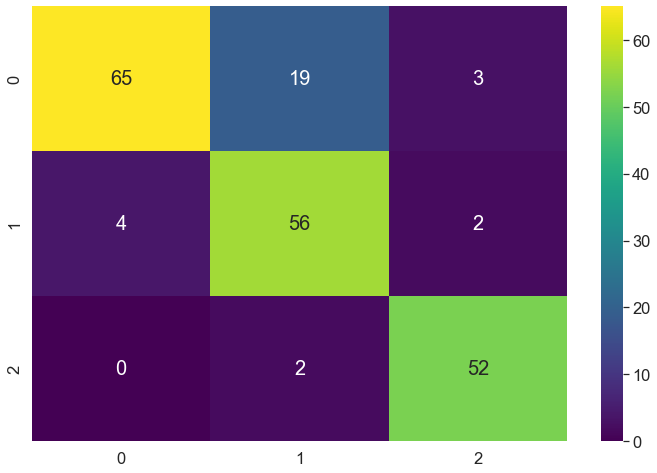

```python
plt.subplots(figsize=(12,8))
cf_matrix = confusion_matrix(y_test, pred)
sns.heatmap(cf_matrix, cmap='viridis',annot = True, annot_kws = {'size':20})
plt.show()
```

From above confusion matrix we can see that 173 class labels are correctly predicted out of 203.

# Normalised Confusion Matrix

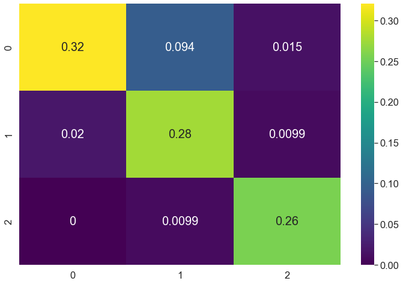

```python
plt.subplots(figsize=(12,8))
cf_matrix = confusion_matrix(y_test, pred)
sns.heatmap(cf_matrix/np.sum(cf_matrix), cmap='viridis',annot = True, annot_kws = {'size':20})
plt.show()
```

From above normalised confusion matrix we can see that 86% class labels are correctly predicted.

```python
data.sample(5)
```

|  | Age | SystolicBP | DiastolicBP | BloodGlucoseLevel | BodyTemp | HeartRate | RiskLevel |
| --- | --- | --- | --- | --- | --- | --- | --- |
| 489 | 30 | 140 | 100 | 15.0 | 98.0 | 70 | 2.0 |
| 383 | 28 | 115 | 60 | 7.8 | 101.0 | 86 | 1.0 |
| 703 | 15 | 100 | 49 | 7.6 | 98.0 | 77 | 0.0 |
| 332 | 23 | 130 | 70 | 6.9 | 98.0 | 70 | 1.0 |
| 886 | 15 | 76 | 49 | 6.8 | 98.0 | 77 | 0.0 |

```python
Age = int(input("Age of pregnant women :"))
SystolicBP = int(input("Systolic BP of women :"))
DiastolicBP = int(input("Diastolic BP of women :"))
BloodGlucoseLevel = float(input("Blood Glucose Level of Pregnant women :"))
BodyTemp = float(input("Body Tmperature of Pregnant women :"))
HeartRate = int(input("Heart Rate of Pregnant women :"))
prediction = rf.predict([[Age,SystolicBP,DiastolicBP,BloodGlucoseLevel,BodyTemp,HeartRate]])
if prediction == 0:
    print("Maternal Health Risk Level is Low.")
elif prediction == 1:
    print("Maternal Health Risk Level is Medium.")
else:
    print("Maternal Health Risk Level is High.")
```

```
Age of pregnant women :23
Systolic BP of women :115
Diastolic BP of women :70
Blood Glucose Level of Pregnant women :7.8
Body Tmperature of Pregnant women :98.4
Heart Rate of Pregnant women :77
Maternal Health Risk Level is High.
```

# Conclusion

Feature Blood Glucose Level has high correalation with target feature Risk Level. Random Forest Model has greater accuracy, hence it does best amongst all the models to be the most accurate. Accuracy of fitted model (Random Forest) on test set is 85%.